# 許循閒

HW14

2019年6月3日

```r
library(readxl)
library(tidyverse)
library(tidyquant)
library(lubridate)
library(broom)
bike_orderlines_tbl <- read_rds("data_wrangled_student/bike_orderlines.rds")

glimpse(bike_orderlines_tbl)
```

```
## Observations: 15,644
## Variables: 13
## $ order_date     <dttm> 2011-01-07, 2011-01-07, 2011-01-10, 2011-01-10...
## $ order_id       <dbl> 1, 1, 2, 2, 3, 3, 3, 3, 3, 4, 5, 5, 5, 5, 6, 6,...
## $ order_line     <dbl> 1, 2, 1, 2, 1, 2, 3, 4, 5, 1, 1, 2, 3, 4, 1, 2,...
## $ quantity       <dbl> 1, 1, 1, 1, 1, 1, 1, 1, 1, 1, 1, 2, 1, 1, 1, 1,...
## $ price          <dbl> 6070, 5970, 2770, 5970, 10660, 3200, 12790, 533...
## $ total_price    <dbl> 6070, 5970, 2770, 5970, 10660, 3200, 12790, 533...
## $ model          <chr> "Jekyll Carbon 2", "Trigger Carbon 2", "Beast o...
## $ category_1     <chr> "Mountain", "Mountain", "Mountain", "Mountain",...
## $ category_2     <chr> "Over Mountain", "Over Mountain", "Trail", "Ove...
## $ frame_material <chr> "Carbon", "Carbon", "Aluminum", "Carbon", "Carb...
## $ bikeshop_name  <chr> "Ithaca Mountain Climbers", "Ithaca Mountain Cl...
## $ city           <chr> "Ithaca", "Ithaca", "Kansas City", "Kansas City...
## $ state          <chr> "NY", "NY", "KS", "KS", "KY", "KY", "KY", "KY",...
```

執行readxl、tidyverse、tidyquant、lubridate、broom

用read_rds讀取檔案

```r
excel_paths_tbl <- fs::dir_info("data/bike_sales/")

paths_chr <- excel_paths_tbl %>%
    pull(path)
```

# Programmatically getting Excel files into R

用fs::dir_info函數將目錄的資料全部讀取

```r
excel_list <- list()
for (path in paths_chr) {
    excel_list[[path]] <- read_excel(path)
}
```

```
## * `` -> ...1
```

```r
excel_list
```

```
## $`data/bike_sales/bikes.xlsx`
## # A tibble: 97 x 4
##    bike.id model                          description                price
##      <dbl> <chr>                          <chr>                      <dbl>
##  1       1 Supersix Evo Black Inc.        Road - Elite Road - Carbon 12790
##  2       2 Supersix Evo Hi-Mod Team       Road - Elite Road - Carbon 10660
##  3       3 Supersix Evo Hi-Mod Dura Ace 1 Road - Elite Road - Carbon  7990
##  4       4 Supersix Evo Hi-Mod Dura Ace 2 Road - Elite Road - Carbon  5330
##  5       5 Supersix Evo Hi-Mod Utegra     Road - Elite Road - Carbon  4260
##  6       6 Supersix Evo Red               Road - Elite Road - Carbon  3940
##  7       7 Supersix Evo Ultegra 3         Road - Elite Road - Carbon  3200
##  8       8 Supersix Evo Ultegra 4         Road - Elite Road - Carbon  2660
##  9       9 Supersix Evo 105               Road - Elite Road - Carbon  2240
## 10      10 Supersix Evo Tiagra            Road - Elite Road - Carbon  1840
## # ... with 87 more rows
##
## $`data/bike_sales/bikeshops.xlsx`
## # A tibble: 30 x 3
##    bikeshop.id bikeshop.name                location
##          <dbl> <chr>                        <chr>
##  1           1 Pittsburgh Mountain Machines Pittsburgh, PA
##  2           2 Ithaca Mountain Climbers     Ithaca, NY
##  3           3 Columbus Race Equipment      Columbus, OH
##  4           4 Detroit Cycles               Detroit, MI
##  5           5 Cincinnati Speed             Cincinnati, OH
##  6           6 Louisville Race Equipment    Louisville, KY
##  7           7 Nashville Cruisers           Nashville, TN
##  8           8 Denver Bike Shop             Denver, CO
##  9           9 Minneapolis Bike Shop        Minneapolis, MN
## 10          10 Kansas City 29ers            Kansas City, KS
## # ... with 20 more rows
##
## $`data/bike_sales/orderlines.xlsx`
## # A tibble: 15,644 x 7
##    ...1  order.id order.line order.date          customer.id product.id
##    <chr>    <dbl>      <dbl> <dttm>                    <dbl>      <dbl>
##  1 1            1          1 2011-01-07 00:00:00           2         48
##  2 2            1          2 2011-01-07 00:00:00           2         52
##  3 3            2          1 2011-01-10 00:00:00          10         76
##  4 4            2          2 2011-01-10 00:00:00          10         52
##  5 5            3          1 2011-01-10 00:00:00           6          2
##  6 6            3          2 2011-01-10 00:00:00           6         50
##  7 7            3          3 2011-01-10 00:00:00           6          1
##  8 8            3          4 2011-01-10 00:00:00           6          4
##  9 9            3          5 2011-01-10 00:00:00           6         34
## 10 10           4          1 2011-01-11 00:00:00          22         26
## # ... with 15,634 more rows, and 1 more variable: quantity <dbl>
```

# What Not To Do: Don’t use for loops

用 for in 迴圈將檔案重複並全部讀取

```r
excel_list_2 <- paths_chr %>%
    map(read_excel) %>%
    set_names(paths_chr)
```

```
## * `` -> ...1
```

# Use map() - Method 1: function name

用map函數讀取全部檔案

set_names函數 - 將名稱命名

```r
paths_chr %>%
    map(~ read_excel(.))
```

```
## * `` -> ...1
```

```
## [[1]]
## # A tibble: 97 x 4
##    bike.id model                          description                price
##      <dbl> <chr>                          <chr>                      <dbl>
##  1       1 Supersix Evo Black Inc.        Road - Elite Road - Carbon 12790
##  2       2 Supersix Evo Hi-Mod Team       Road - Elite Road - Carbon 10660
##  3       3 Supersix Evo Hi-Mod Dura Ace 1 Road - Elite Road - Carbon  7990
##  4       4 Supersix Evo Hi-Mod Dura Ace 2 Road - Elite Road - Carbon  5330
##  5       5 Supersix Evo Hi-Mod Utegra     Road - Elite Road - Carbon  4260
##  6       6 Supersix Evo Red               Road - Elite Road - Carbon  3940
##  7       7 Supersix Evo Ultegra 3         Road - Elite Road - Carbon  3200
##  8       8 Supersix Evo Ultegra 4         Road - Elite Road - Carbon  2660
##  9       9 Supersix Evo 105               Road - Elite Road - Carbon  2240
## 10      10 Supersix Evo Tiagra            Road - Elite Road - Carbon  1840
## # ... with 87 more rows
##
## [[2]]
## # A tibble: 30 x 3
##    bikeshop.id bikeshop.name                location
##          <dbl> <chr>                        <chr>
##  1           1 Pittsburgh Mountain Machines Pittsburgh, PA
##  2           2 Ithaca Mountain Climbers     Ithaca, NY
##  3           3 Columbus Race Equipment      Columbus, OH
##  4           4 Detroit Cycles               Detroit, MI
##  5           5 Cincinnati Speed             Cincinnati, OH
##  6           6 Louisville Race Equipment    Louisville, KY
##  7           7 Nashville Cruisers           Nashville, TN
##  8           8 Denver Bike Shop             Denver, CO
##  9           9 Minneapolis Bike Shop        Minneapolis, MN
## 10          10 Kansas City 29ers            Kansas City, KS
## # ... with 20 more rows
##
## [[3]]
## # A tibble: 15,644 x 7
##    ...1  order.id order.line order.date          customer.id product.id
##    <chr>    <dbl>      <dbl> <dttm>                    <dbl>      <dbl>
##  1 1            1          1 2011-01-07 00:00:00           2         48
##  2 2            1          2 2011-01-07 00:00:00           2         52
##  3 3            2          1 2011-01-10 00:00:00          10         76
##  4 4            2          2 2011-01-10 00:00:00          10         52
##  5 5            3          1 2011-01-10 00:00:00           6          2
##  6 6            3          2 2011-01-10 00:00:00           6         50
##  7 7            3          3 2011-01-10 00:00:00           6          1
##  8 8            3          4 2011-01-10 00:00:00           6          4
##  9 9            3          5 2011-01-10 00:00:00           6         34
## 10 10           4          1 2011-01-11 00:00:00          22         26
## # ... with 15,634 more rows, and 1 more variable: quantity <dbl>
```

# Use map() - Method 2: Anonymous Function

用map函數讀取全部檔案

```r
paths_chr %>%
    map(function(x) read_excel(path = x))
```

```
## * `` -> ...1
```

```
## [[1]]
## # A tibble: 97 x 4
##    bike.id model                          description                price
##      <dbl> <chr>                          <chr>                      <dbl>
##  1       1 Supersix Evo Black Inc.        Road - Elite Road - Carbon 12790
##  2       2 Supersix Evo Hi-Mod Team       Road - Elite Road - Carbon 10660
##  3       3 Supersix Evo Hi-Mod Dura Ace 1 Road - Elite Road - Carbon  7990
##  4       4 Supersix Evo Hi-Mod Dura Ace 2 Road - Elite Road - Carbon  5330
##  5       5 Supersix Evo Hi-Mod Utegra     Road - Elite Road - Carbon  4260
##  6       6 Supersix Evo Red               Road - Elite Road - Carbon  3940
##  7       7 Supersix Evo Ultegra 3         Road - Elite Road - Carbon  3200
##  8       8 Supersix Evo Ultegra 4         Road - Elite Road - Carbon  2660
##  9       9 Supersix Evo 105               Road - Elite Road - Carbon  2240
## 10      10 Supersix Evo Tiagra            Road - Elite Road - Carbon  1840
## # ... with 87 more rows
##
## [[2]]
## # A tibble: 30 x 3
##    bikeshop.id bikeshop.name                location
##          <dbl> <chr>                        <chr>
##  1           1 Pittsburgh Mountain Machines Pittsburgh, PA
##  2           2 Ithaca Mountain Climbers     Ithaca, NY
##  3           3 Columbus Race Equipment      Columbus, OH
##  4           4 Detroit Cycles               Detroit, MI
##  5           5 Cincinnati Speed             Cincinnati, OH
##  6           6 Louisville Race Equipment    Louisville, KY
##  7           7 Nashville Cruisers           Nashville, TN
##  8           8 Denver Bike Shop             Denver, CO
##  9           9 Minneapolis Bike Shop        Minneapolis, MN
## 10          10 Kansas City 29ers            Kansas City, KS
## # ... with 20 more rows
##
## [[3]]
## # A tibble: 15,644 x 7
##    ...1  order.id order.line order.date          customer.id product.id
##    <chr>    <dbl>      <dbl> <dttm>                    <dbl>      <dbl>
##  1 1            1          1 2011-01-07 00:00:00           2         48
##  2 2            1          2 2011-01-07 00:00:00           2         52
##  3 3            2          1 2011-01-10 00:00:00          10         76
##  4 4            2          2 2011-01-10 00:00:00          10         52
##  5 5            3          1 2011-01-10 00:00:00           6          2
##  6 6            3          2 2011-01-10 00:00:00           6         50
##  7 7            3          3 2011-01-10 00:00:00           6          1
##  8 8            3          4 2011-01-10 00:00:00           6          4
##  9 9            3          5 2011-01-10 00:00:00           6         34
## 10 10           4          1 2011-01-11 00:00:00          22         26
## # ... with 15,634 more rows, and 1 more variable: quantity <dbl>
```

# Use map() - Function specified with function()

用map函數讀取全部檔案

```r
excel_sheets("data/bike_sales/bikes.xlsx") %>%
    map(~ read_excel(path = "data/bike_sales/bikes.xlsx", sheet = .))
```

```
## [[1]]
## # A tibble: 97 x 4
##    bike.id model                          description                price
##      <dbl> <chr>                          <chr>                      <dbl>
##  1       1 Supersix Evo Black Inc.        Road - Elite Road - Carbon 12790
##  2       2 Supersix Evo Hi-Mod Team       Road - Elite Road - Carbon 10660
##  3       3 Supersix Evo Hi-Mod Dura Ace 1 Road - Elite Road - Carbon  7990
##  4       4 Supersix Evo Hi-Mod Dura Ace 2 Road - Elite Road - Carbon  5330
##  5       5 Supersix Evo Hi-Mod Utegra     Road - Elite Road - Carbon  4260
##  6       6 Supersix Evo Red               Road - Elite Road - Carbon  3940
##  7       7 Supersix Evo Ultegra 3         Road - Elite Road - Carbon  3200
##  8       8 Supersix Evo Ultegra 4         Road - Elite Road - Carbon  2660
##  9       9 Supersix Evo 105               Road - Elite Road - Carbon  2240
## 10      10 Supersix Evo Tiagra            Road - Elite Road - Carbon  1840
## # ... with 87 more rows
```

# Reading Excel Sheets

用map函數讀取全部檔案

```r
bike_orderlines_tbl %>% is.list()
```

```
## [1] TRUE
```

```r
bike_orderlines_tbl %>%
    map(~ class(.))
```

```
## $order_date
## [1] "POSIXct" "POSIXt"
##
## $order_id
## [1] "numeric"
##
## $order_line
## [1] "numeric"
##
## $quantity
## [1] "numeric"
##
## $price
## [1] "numeric"
##
## $total_price
## [1] "numeric"
##
## $model
## [1] "character"
##
## $category_1
## [1] "character"
##
## $category_2
## [1] "character"
##
## $frame_material
## [1] "character"
##
## $bikeshop_name
## [1] "character"
##
## $city
## [1] "character"
##
## $state
## [1] "character"
```

# Column-wise Map

```r
bike_orderlines_tbl %>%
    map_chr(~ class(.)[1])
```

```
##     order_date       order_id     order_line       quantity          price
##      "POSIXct"      "numeric"      "numeric"      "numeric"      "numeric"
##    total_price          model     category_1     category_2 frame_material
##      "numeric"    "character"    "character"    "character"    "character"
##  bikeshop_name           city          state
##    "character"    "character"    "character"
```

# Character map

用map_chr將資料輸出成文字形式

```r
bike_orderlines_tbl %>%
    map_df(~ class(.)[1]) %>%
    gather()
```

```
## # A tibble: 13 x 2
##    key            value
##    <chr>          <chr>
##  1 order_date     POSIXct
##  2 order_id       numeric
##  3 order_line     numeric
##  4 quantity       numeric
##  5 price          numeric
##  6 total_price    numeric
##  7 model          character
##  8 category_1     character
##  9 category_2     character
## 10 frame_material character
## 11 bikeshop_name  character
## 12 city           character
## 13 state          character
```

```r
bike_orderlines_tbl %>%
    map_df(~ sum(is.na(.)) / length(.)) %>%
    gather()
```

```
## # A tibble: 13 x 2
##    key            value
##    <chr>          <dbl>
##  1 order_date         0
##  2 order_id           0
##  3 order_line         0
##  4 quantity           0
##  5 price              0
##  6 total_price        0
##  7 model              0
##  8 category_1         0
##  9 category_2         0
## 10 frame_material     0
## 11 bikeshop_name      0
## 12 city               0
## 13 state              0
```

# Data Frame map

用map_df將資料輸出成資料格式

map_df(~ sum(is.na(.)) / length(.)) - 計算資料na的比例

```r
excel_tbl <- excel_paths_tbl %>%
    select(path) %>%
    mutate(data = path %>% map(read_excel))
```

```
## * `` -> ...1
```

```r
excel_list
```

```
## $`data/bike_sales/bikes.xlsx`
## # A tibble: 97 x 4
##    bike.id model                          description                price
##      <dbl> <chr>                          <chr>                      <dbl>
##  1       1 Supersix Evo Black Inc.        Road - Elite Road - Carbon 12790
##  2       2 Supersix Evo Hi-Mod Team       Road - Elite Road - Carbon 10660
##  3       3 Supersix Evo Hi-Mod Dura Ace 1 Road - Elite Road - Carbon  7990
##  4       4 Supersix Evo Hi-Mod Dura Ace 2 Road - Elite Road - Carbon  5330
##  5       5 Supersix Evo Hi-Mod Utegra     Road - Elite Road - Carbon  4260
##  6       6 Supersix Evo Red               Road - Elite Road - Carbon  3940
##  7       7 Supersix Evo Ultegra 3         Road - Elite Road - Carbon  3200
##  8       8 Supersix Evo Ultegra 4         Road - Elite Road - Carbon  2660
##  9       9 Supersix Evo 105               Road - Elite Road - Carbon  2240
## 10      10 Supersix Evo Tiagra            Road - Elite Road - Carbon  1840
## # ... with 87 more rows
##
## $`data/bike_sales/bikeshops.xlsx`
## # A tibble: 30 x 3
##    bikeshop.id bikeshop.name                location
##          <dbl> <chr>                        <chr>
##  1           1 Pittsburgh Mountain Machines Pittsburgh, PA
##  2           2 Ithaca Mountain Climbers     Ithaca, NY
##  3           3 Columbus Race Equipment      Columbus, OH
##  4           4 Detroit Cycles               Detroit, MI
##  5           5 Cincinnati Speed             Cincinnati, OH
##  6           6 Louisville Race Equipment    Louisville, KY
##  7           7 Nashville Cruisers           Nashville, TN
##  8           8 Denver Bike Shop             Denver, CO
##  9           9 Minneapolis Bike Shop        Minneapolis, MN
## 10          10 Kansas City 29ers            Kansas City, KS
## # ... with 20 more rows
##
## $`data/bike_sales/orderlines.xlsx`
## # A tibble: 15,644 x 7
##    ...1  order.id order.line order.date          customer.id product.id
##    <chr>    <dbl>      <dbl> <dttm>                    <dbl>      <dbl>
##  1 1            1          1 2011-01-07 00:00:00           2         48
##  2 2            1          2 2011-01-07 00:00:00           2         52
##  3 3            2          1 2011-01-10 00:00:00          10         76
##  4 4            2          2 2011-01-10 00:00:00          10         52
##  5 5            3          1 2011-01-10 00:00:00           6          2
##  6 6            3          2 2011-01-10 00:00:00           6         50
##  7 7            3          3 2011-01-10 00:00:00           6          1
##  8 8            3          4 2011-01-10 00:00:00           6          4
##  9 9            3          5 2011-01-10 00:00:00           6         34
## 10 10           4          1 2011-01-11 00:00:00          22         26
## # ... with 15,634 more rows, and 1 more variable: quantity <dbl>
```

```r
excel_tbl
```

```
## # A tibble: 3 x 2
##   path                            data
##   <fs::path>                      <list>
## 1 data/bike_sales/bikes.xlsx      <tibble [97 x 4]>
## 2 data/bike_sales/bikeshops.xlsx  <tibble [30 x 3]>
## 3 data/bike_sales/orderlines.xlsx <tibble [15,644 x 7]>
```

# Row-wise Map

用select函數選擇路徑

用mutate函數新增欄位

```r
excel_tbl
```

```
## # A tibble: 3 x 2
##   path                            data
##   <fs::path>                      <list>
## 1 data/bike_sales/bikes.xlsx      <tibble [97 x 4]>
## 2 data/bike_sales/bikeshops.xlsx  <tibble [30 x 3]>
## 3 data/bike_sales/orderlines.xlsx <tibble [15,644 x 7]>
```

```r
excel_tbl$data
```

```
## [[1]]
## # A tibble: 97 x 4
##    bike.id model                          description                price
##      <dbl> <chr>                          <chr>                      <dbl>
##  1       1 Supersix Evo Black Inc.        Road - Elite Road - Carbon 12790
##  2       2 Supersix Evo Hi-Mod Team       Road - Elite Road - Carbon 10660
##  3       3 Supersix Evo Hi-Mod Dura Ace 1 Road - Elite Road - Carbon  7990
##  4       4 Supersix Evo Hi-Mod Dura Ace 2 Road - Elite Road - Carbon  5330
##  5       5 Supersix Evo Hi-Mod Utegra     Road - Elite Road - Carbon  4260
##  6       6 Supersix Evo Red               Road - Elite Road - Carbon  3940
##  7       7 Supersix Evo Ultegra 3         Road - Elite Road - Carbon  3200
##  8       8 Supersix Evo Ultegra 4         Road - Elite Road - Carbon  2660
##  9       9 Supersix Evo 105               Road - Elite Road - Carbon  2240
## 10      10 Supersix Evo Tiagra            Road - Elite Road - Carbon  1840
## # ... with 87 more rows
##
## [[2]]
## # A tibble: 30 x 3
##    bikeshop.id bikeshop.name                location
##          <dbl> <chr>                        <chr>
##  1           1 Pittsburgh Mountain Machines Pittsburgh, PA
##  2           2 Ithaca Mountain Climbers     Ithaca, NY
##  3           3 Columbus Race Equipment      Columbus, OH
##  4           4 Detroit Cycles               Detroit, MI
##  5           5 Cincinnati Speed             Cincinnati, OH
##  6           6 Louisville Race Equipment    Louisville, KY
##  7           7 Nashville Cruisers           Nashville, TN
##  8           8 Denver Bike Shop             Denver, CO
##  9           9 Minneapolis Bike Shop        Minneapolis, MN
## 10          10 Kansas City 29ers            Kansas City, KS
## # ... with 20 more rows
##
## [[3]]
## # A tibble: 15,644 x 7
##    ...1  order.id order.line order.date          customer.id product.id
##    <chr>    <dbl>      <dbl> <dttm>                    <dbl>      <dbl>
##  1 1            1          1 2011-01-07 00:00:00           2         48
##  2 2            1          2 2011-01-07 00:00:00           2         52
##  3 3            2          1 2011-01-10 00:00:00          10         76
##  4 4            2          2 2011-01-10 00:00:00          10         52
##  5 5            3          1 2011-01-10 00:00:00           6          2
##  6 6            3          2 2011-01-10 00:00:00           6         50
##  7 7            3          3 2011-01-10 00:00:00           6          1
##  8 8            3          4 2011-01-10 00:00:00           6          4
##  9 9            3          5 2011-01-10 00:00:00           6         34
## 10 10           4          1 2011-01-11 00:00:00          22         26
## # ... with 15,634 more rows, and 1 more variable: quantity <dbl>
```

```r
excel_tbl$data[[3]]
```

```
## # A tibble: 15,644 x 7
##    ...1  order.id order.line order.date          customer.id product.id
##    <chr>    <dbl>      <dbl> <dttm>                    <dbl>      <dbl>
##  1 1            1          1 2011-01-07 00:00:00           2         48
##  2 2            1          2 2011-01-07 00:00:00           2         52
##  3 3            2          1 2011-01-10 00:00:00          10         76
##  4 4            2          2 2011-01-10 00:00:00          10         52
##  5 5            3          1 2011-01-10 00:00:00           6          2
##  6 6            3          2 2011-01-10 00:00:00           6         50
##  7 7            3          3 2011-01-10 00:00:00           6          1
##  8 8            3          4 2011-01-10 00:00:00           6          4
##  9 9            3          5 2011-01-10 00:00:00           6         34
## 10 10           4          1 2011-01-11 00:00:00          22         26
## # ... with 15,634 more rows, and 1 more variable: quantity <dbl>
```

```r
excel_tbl_unnested <- excel_tbl %>%
    unnest(data, .id = 'ID')
excel_tbl_unnested
```

```
## # A tibble: 15,771 x 16
##    path       ID    bike.id model description price bikeshop.id
##    <fs::path> <chr>   <dbl> <chr> <chr>       <dbl>       <dbl>
##  1 data/bike~ 1           1 Supe~ Road - Eli~ 12790          NA
##  2 data/bike~ 1           2 Supe~ Road - Eli~ 10660          NA
##  3 data/bike~ 1           3 Supe~ Road - Eli~  7990          NA
##  4 data/bike~ 1           4 Supe~ Road - Eli~  5330          NA
##  5 data/bike~ 1           5 Supe~ Road - Eli~  4260          NA
##  6 data/bike~ 1           6 Supe~ Road - Eli~  3940          NA
##  7 data/bike~ 1           7 Supe~ Road - Eli~  3200          NA
##  8 data/bike~ 1           8 Supe~ Road - Eli~  2660          NA
##  9 data/bike~ 1           9 Supe~ Road - Eli~  2240          NA
## 10 data/bike~ 1          10 Supe~ Road - Eli~  1840          NA
## # ... with 15,761 more rows, and 9 more variables: bikeshop.name <chr>,
## #   location <chr>, ...1 <chr>, order.id <dbl>, order.line <dbl>,
## #   order.date <dttm>, customer.id <dbl>, product.id <dbl>, quantity <dbl>
```

# Unnest

用unnested將資料合併

unnest(data, .id = ‘ID’) - 可以看出資料是從哪個部分讀取的

```r
excel_tbl_nested <- excel_tbl_unnested %>%
    group_by(ID, path) %>%
    nest()

excel_tbl_nested$data
```

```
## [[1]]
## # A tibble: 97 x 14
##    bike.id model description price bikeshop.id bikeshop.name location ...1
##      <dbl> <chr> <chr>       <dbl>       <dbl> <chr>         <chr>    <chr>
##  1       1 Supe~ Road - Eli~ 12790          NA <NA>          <NA>     <NA>
##  2       2 Supe~ Road - Eli~ 10660          NA <NA>          <NA>     <NA>
##  3       3 Supe~ Road - Eli~  7990          NA <NA>          <NA>     <NA>
##  4       4 Supe~ Road - Eli~  5330          NA <NA>          <NA>     <NA>
##  5       5 Supe~ Road - Eli~  4260          NA <NA>          <NA>     <NA>
##  6       6 Supe~ Road - Eli~  3940          NA <NA>          <NA>     <NA>
##  7       7 Supe~ Road - Eli~  3200          NA <NA>          <NA>     <NA>
##  8       8 Supe~ Road - Eli~  2660          NA <NA>          <NA>     <NA>
##  9       9 Supe~ Road - Eli~  2240          NA <NA>          <NA>     <NA>
## 10      10 Supe~ Road - Eli~  1840          NA <NA>          <NA>     <NA>
## # ... with 87 more rows, and 6 more variables: order.id <dbl>,
## #   order.line <dbl>, order.date <dttm>, customer.id <dbl>,
## #   product.id <dbl>, quantity <dbl>
##
## [[2]]
## # A tibble: 30 x 14
##    bike.id model description price bikeshop.id bikeshop.name location ...1
##      <dbl> <chr> <chr>       <dbl>       <dbl> <chr>         <chr>    <chr>
##  1      NA <NA>  <NA>           NA           1 Pittsburgh M~ Pittsbu~ <NA>
##  2      NA <NA>  <NA>           NA           2 Ithaca Mount~ Ithaca,~ <NA>
##  3      NA <NA>  <NA>           NA           3 Columbus Rac~ Columbu~ <NA>
##  4      NA <NA>  <NA>           NA           4 Detroit Cycl~ Detroit~ <NA>
##  5      NA <NA>  <NA>           NA           5 Cincinnati S~ Cincinn~ <NA>
##  6      NA <NA>  <NA>           NA           6 Louisville R~ Louisvi~ <NA>
##  7      NA <NA>  <NA>           NA           7 Nashville Cr~ Nashvil~ <NA>
##  8      NA <NA>  <NA>           NA           8 Denver Bike ~ Denver,~ <NA>
##  9      NA <NA>  <NA>           NA           9 Minneapolis ~ Minneap~ <NA>
## 10      NA <NA>  <NA>           NA          10 Kansas City ~ Kansas ~ <NA>
## # ... with 20 more rows, and 6 more variables: order.id <dbl>,
## #   order.line <dbl>, order.date <dttm>, customer.id <dbl>,
## #   product.id <dbl>, quantity <dbl>
##
## [[3]]
## # A tibble: 15,644 x 14
##    bike.id model description price bikeshop.id bikeshop.name location ...1
##      <dbl> <chr> <chr>       <dbl>       <dbl> <chr>         <chr>    <chr>
##  1      NA <NA>  <NA>           NA          NA <NA>          <NA>     1
##  2      NA <NA>  <NA>           NA          NA <NA>          <NA>     2
##  3      NA <NA>  <NA>           NA          NA <NA>          <NA>     3
##  4      NA <NA>  <NA>           NA          NA <NA>          <NA>     4
##  5      NA <NA>  <NA>           NA          NA <NA>          <NA>     5
##  6      NA <NA>  <NA>           NA          NA <NA>          <NA>     6
##  7      NA <NA>  <NA>           NA          NA <NA>          <NA>     7
##  8      NA <NA>  <NA>           NA          NA <NA>          <NA>     8
##  9      NA <NA>  <NA>           NA          NA <NA>          <NA>     9
## 10      NA <NA>  <NA>           NA          NA <NA>          <NA>     10
## # ... with 15,634 more rows, and 6 more variables: order.id <dbl>,
## #   order.line <dbl>, order.date <dttm>, customer.id <dbl>,
## #   product.id <dbl>, quantity <dbl>
```

# Nest

nest()將資料還原(合併後的一些資料不會消失，會一起呈現)

```r
x <- rep(NA, 5)
x
```

```
## [1] NA NA NA NA NA
```

```r
!is.na(x) %>% all()
```

```
## [1] FALSE
```

```r
y <- c(1:4, NA_real_)
y
```

```
## [1]  1  2  3  4 NA
```

```r
!is.na(y) %>% all()
```

```
## [1] TRUE
```

```r
all(!is.na(y))
```

```
## [1] FALSE
```

```r
excel_tbl_nested$data[[1]] %>%
    select_if(~ !is.na(.) %>% all())
```

```
## # A tibble: 97 x 4
##    bike.id model                          description                price
##      <dbl> <chr>                          <chr>                      <dbl>
##  1       1 Supersix Evo Black Inc.        Road - Elite Road - Carbon 12790
##  2       2 Supersix Evo Hi-Mod Team       Road - Elite Road - Carbon 10660
##  3       3 Supersix Evo Hi-Mod Dura Ace 1 Road - Elite Road - Carbon  7990
##  4       4 Supersix Evo Hi-Mod Dura Ace 2 Road - Elite Road - Carbon  5330
##  5       5 Supersix Evo Hi-Mod Utegra     Road - Elite Road - Carbon  4260
##  6       6 Supersix Evo Red               Road - Elite Road - Carbon  3940
##  7       7 Supersix Evo Ultegra 3         Road - Elite Road - Carbon  3200
##  8       8 Supersix Evo Ultegra 4         Road - Elite Road - Carbon  2660
##  9       9 Supersix Evo 105               Road - Elite Road - Carbon  2240
## 10      10 Supersix Evo Tiagra            Road - Elite Road - Carbon  1840
## # ... with 87 more rows
```

```r
excel_tbl_nested
```

```
## # A tibble: 3 x 3
##   ID    path                            data
##   <chr> <fs::path>                      <list>
## 1 1     data/bike_sales/bikes.xlsx      <tibble [97 x 14]>
## 2 2     data/bike_sales/bikeshops.xlsx  <tibble [30 x 14]>
## 3 3     data/bike_sales/orderlines.xlsx <tibble [15,644 x 14]>
```

# Mapping Nested List Columns

用select_if函數排除有na的資料

```r
select_non_na_columns <- function(data) {
    data %>%
        select_if(~ !is.na(.) %>% all())
}
```

# Creating a function outside of purrr::map() - Create a function that can be mapped to one element

用select_if函數排除有na的資料料

```r
excel_tbl_nested$data[[1]] %>%
    select_non_na_columns()
```

```
## # A tibble: 97 x 4
##    bike.id model                          description                price
##      <dbl> <chr>                          <chr>                      <dbl>
##  1       1 Supersix Evo Black Inc.        Road - Elite Road - Carbon 12790
##  2       2 Supersix Evo Hi-Mod Team       Road - Elite Road - Carbon 10660
##  3       3 Supersix Evo Hi-Mod Dura Ace 1 Road - Elite Road - Carbon  7990
##  4       4 Supersix Evo Hi-Mod Dura Ace 2 Road - Elite Road - Carbon  5330
##  5       5 Supersix Evo Hi-Mod Utegra     Road - Elite Road - Carbon  4260
##  6       6 Supersix Evo Red               Road - Elite Road - Carbon  3940
##  7       7 Supersix Evo Ultegra 3         Road - Elite Road - Carbon  3200
##  8       8 Supersix Evo Ultegra 4         Road - Elite Road - Carbon  2660
##  9       9 Supersix Evo 105               Road - Elite Road - Carbon  2240
## 10      10 Supersix Evo Tiagra            Road - Elite Road - Carbon  1840
## # ... with 87 more rows
```

# Creating a function outside of purrr::map() - Extract an element, and test the function

從excel_tbl_nested$data中選擇沒有na的欄位

```r
excel_tbl_nested_fixed <- excel_tbl_nested %>%
    mutate(data_fixed = data %>% map(select_non_na_columns))

excel_tbl_nested_fixed$data[[1]]
```

```
## # A tibble: 97 x 14
##    bike.id model description price bikeshop.id bikeshop.name location ...1
##      <dbl> <chr> <chr>       <dbl>       <dbl> <chr>         <chr>    <chr>
##  1       1 Supe~ Road - Eli~ 12790          NA <NA>          <NA>     <NA>
##  2       2 Supe~ Road - Eli~ 10660          NA <NA>          <NA>     <NA>
##  3       3 Supe~ Road - Eli~  7990          NA <NA>          <NA>     <NA>
##  4       4 Supe~ Road - Eli~  5330          NA <NA>          <NA>     <NA>
##  5       5 Supe~ Road - Eli~  4260          NA <NA>          <NA>     <NA>
##  6       6 Supe~ Road - Eli~  3940          NA <NA>          <NA>     <NA>
##  7       7 Supe~ Road - Eli~  3200          NA <NA>          <NA>     <NA>
##  8       8 Supe~ Road - Eli~  2660          NA <NA>          <NA>     <NA>
##  9       9 Supe~ Road - Eli~  2240          NA <NA>          <NA>     <NA>
## 10      10 Supe~ Road - Eli~  1840          NA <NA>          <NA>     <NA>
## # ... with 87 more rows, and 6 more variables: order.id <dbl>,
## #   order.line <dbl>, order.date <dttm>, customer.id <dbl>,
## #   product.id <dbl>, quantity <dbl>
```

# Creating a function outside of purrr::map() - Use mutate() + map()

mutate函數新增修改後的資料欄位(從select_non_na_columns)

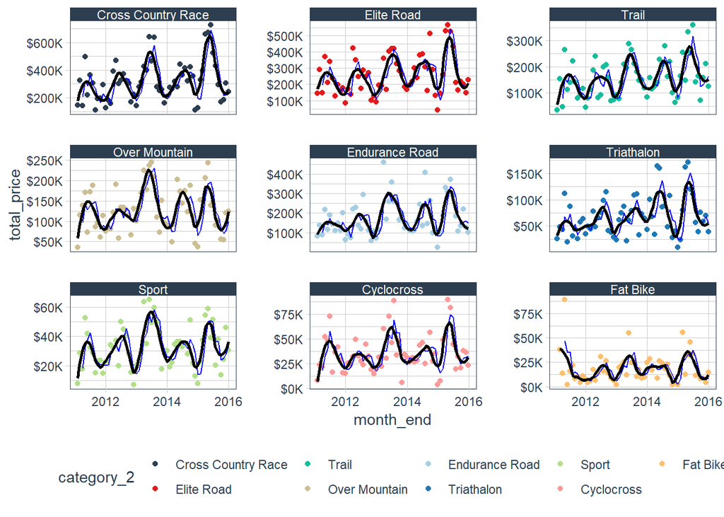

```r
rolling_avg_3_tbl <- bike_orderlines_tbl %>%
    select(order_date, category_1, category_2, total_price) %>%
    mutate(order_date = ymd(order_date)) %>%
    mutate(month_end = ceiling_date(order_date, unit = "month") - period(1, unit = "days")) %>%
    group_by(category_1, category_2, month_end) %>%
    summarise(
        total_price = sum(total_price)
    ) %>%
    mutate(rolling_avg_3 = rollmean(total_price, k = 3, fill = NA, align = 'right')) %>%
    ungroup() %>%
    mutate(category_2 = as_factor(category_2) %>% fct_reorder2(month_end, total_price))

rolling_avg_3_tbl %>%
    ggplot(aes(month_end, total_price, color = category_2)) +
    geom_point() +
    geom_line(aes(y = rolling_avg_3), color = "blue", linetype = 1) +
    facet_wrap(~ category_2, scales = "free_y") +
    geom_smooth(method = "loess", se = FALSE, span = 0.2, color = "black") +
    theme_tq() +
    scale_color_tq() +
    scale_y_continuous(labels = scales::dollar_format(scale = 1e-3, suffix = "K"))
```

# Code comes from 04_functions_iteration/01_functional_programming

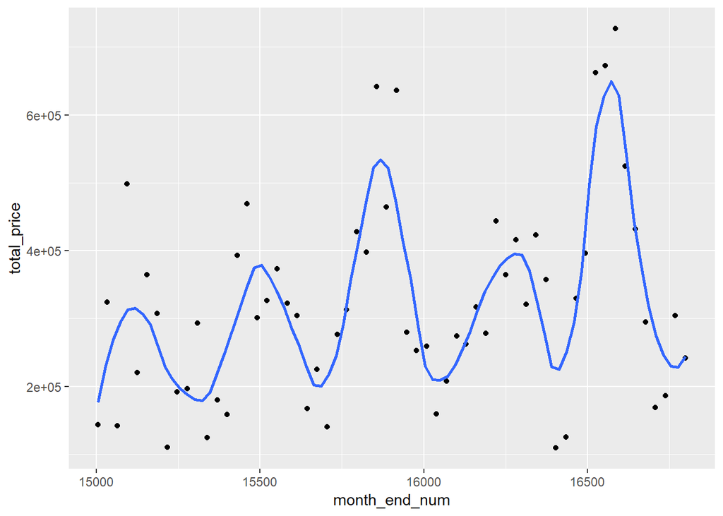

```r
sales_by_m_cross_country_tbl <- rolling_avg_3_tbl %>%
    filter(category_2 == "Cross Country Race") %>%
    select(month_end, total_price) %>%
    mutate(month_end_num = as.numeric(month_end))

sales_by_m_cross_country_tbl %>%
    ggplot(aes(month_end_num, total_price)) +
    geom_point() +
    geom_smooth(method = "loess", span = 0.2, se = FALSE)
```

# Data Preparation

```r
fit_loess_cross_country <- sales_by_m_cross_country_tbl %>%
    loess(total_price ~ month_end_num, data = ., span = 0.2)

fit_loess_cross_country
```

```
## Call:
## loess(formula = total_price ~ month_end_num, data = ., span = 0.2)
##
## Number of Observations: 60
## Equivalent Number of Parameters: 14.69
## Residual Standard Error: 89070
```

# Making a loess model

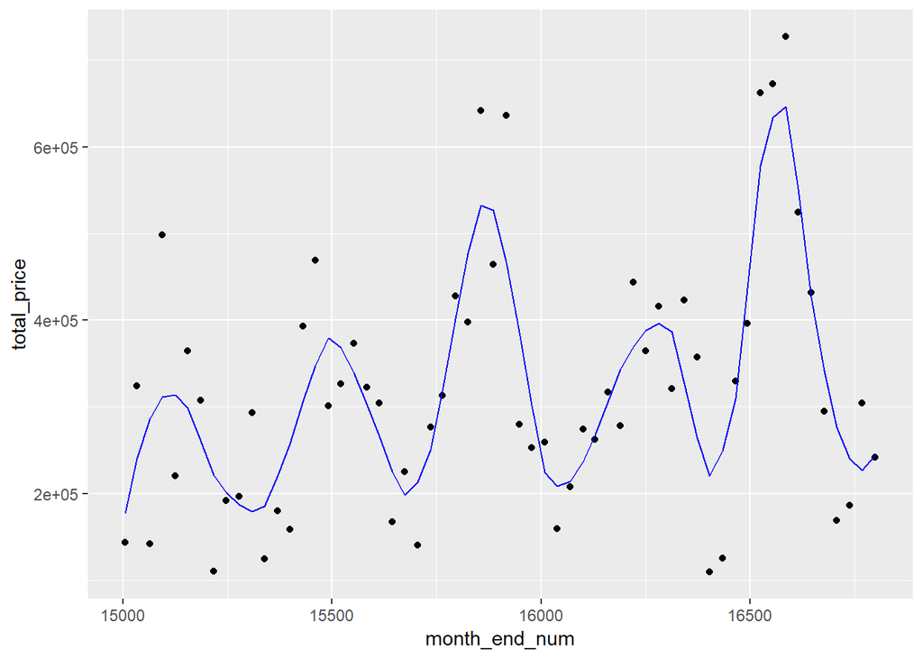

```r
fit_loess_cross_country %>%
    broom::augment() %>%
    ggplot(aes(month_end_num, total_price)) +
    geom_point() +
    geom_line(aes(y = .fitted), color = "blue")
```

# Working With Broom

```r
rolling_avg_3_tbl_nested <- rolling_avg_3_tbl %>%
    group_by(category_1, category_2) %>%
    nest()

rolling_avg_3_tbl_nested$data[[1]]
```

```
## # A tibble: 60 x 3
##    month_end  total_price rolling_avg_3
##    <date>           <dbl>         <dbl>
##  1 2011-01-31      143660           NA
##  2 2011-02-28      324400           NA
##  3 2011-03-31      142000       203353.
##  4 2011-04-30      498580       321660
##  5 2011-05-31      220310       286963.
##  6 2011-06-30      364420       361103.
##  7 2011-07-31      307300       297343.
##  8 2011-08-31      110600       260773.
##  9 2011-09-30      191870       203257.
## 10 2011-10-31      196440       166303.
## # ... with 50 more rows
```

```r
data <- rolling_avg_3_tbl_nested$data[[1]]

tidy_loess <- function(data, span = 0.2) {
    data_formatted <- data %>%
        select(month_end, total_price) %>%
        mutate(month_end_num = as.numeric(month_end))
    fit_loess <- loess(formula = total_price ~ month_end_num,
                       data    = data_formatted,
                       span    = span)
    output_tbl <- fit_loess %>%
        broom::augment() %>%
        select(.fitted)
    return(output_tbl)
}
```

# Function To Return Fitted Results

```r
rolling_avg_3_tbl_nested$data[[2]] %>%
    tidy_loess()
```

```
## # A tibble: 58 x 1
##    .fitted
##      <dbl>
##  1  39170.
##  2  36927.
##  3  33231.
##  4  28581.
##  5  20731.
##  6  12102.
##  7  10050.
##  8  10024.
##  9   8033.
## 10   6620.
## # ... with 48 more rows
```

# Test Function on Single Element

```r
loess_tbl_nested <- rolling_avg_3_tbl_nested %>%
    mutate(fitted = data %>% map(tidy_loess))

loess_tbl_nested$fitted[[1]]
```

```
## # A tibble: 60 x 1
##    .fitted
##      <dbl>
##  1 176998.
##  2 239802.
##  3 286279.
##  4 311685.
##  5 313621.
##  6 298642.
##  7 261073.
##  8 221223.
##  9 201690.
## 10 187415.
## # ... with 50 more rows
```

```r
loess_tbl_nested %>%
    unnest()
```

```
## # A tibble: 538 x 6
##    category_1 category_2       month_end  total_price rolling_avg_3 .fitted
##    <chr>      <fct>            <date>           <dbl>         <dbl>   <dbl>
##  1 Mountain   Cross Country R~ 2011-01-31      143660           NA  176998.
##  2 Mountain   Cross Country R~ 2011-02-28      324400           NA  239802.
##  3 Mountain   Cross Country R~ 2011-03-31      142000       203353. 286279.
##  4 Mountain   Cross Country R~ 2011-04-30      498580       321660  311685.
##  5 Mountain   Cross Country R~ 2011-05-31      220310       286963. 313621.
##  6 Mountain   Cross Country R~ 2011-06-30      364420       361103. 298642.
##  7 Mountain   Cross Country R~ 2011-07-31      307300       297343. 261073.
##  8 Mountain   Cross Country R~ 2011-08-31      110600       260773. 221223.
##  9 Mountain   Cross Country R~ 2011-09-30      191870       203257. 201690.
## 10 Mountain   Cross Country R~ 2011-10-31      196440       166303. 187415.
## # ... with 528 more rows
```

# Map Functions

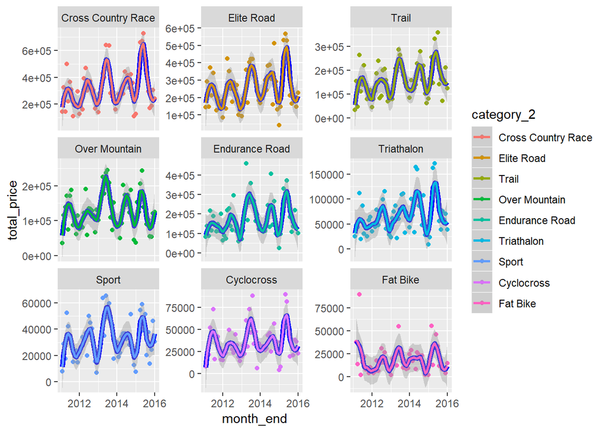

```r
loess_tbl_nested %>%
    unnest() %>%
    ggplot(aes(month_end, total_price, color = category_2)) +
    geom_point() +
    geom_line(aes(y = .fitted), color = "blue", size = 2) +
    geom_smooth(method = "loess", span = 0.2) +
    facet_wrap(~ category_2, scales = "free_y")
```

# Visualize Results